# Pemeriksaan Kestasioneritasan Data

Farhan Abdillah Harahap (G1401211007)

```r
library(ggplot2)
library(tsibble)
library(tseries)
library(MASS)
```

```r
set.seed(007)
```

## Data

```r
stas <- data<- rio::import("https://raw.githubusercontent.com/farhanabdillahh/PraktikumMPDW/main/data/datasetmpdw.csv")
stas <- ts(data$value)
```

### Plot *Time Series*

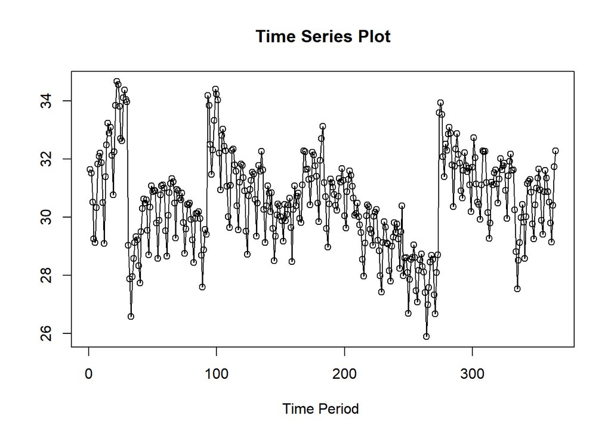

```r
library(ggplot2)
plot_stas <- ts.plot(stas, xlab="Time Period ", ylab="",
        main = "Time Series Plot")
points(stas)
```

Plot deret waktu di atas menunjukkan bahwa data cenderung membuat grafik stasioner. Pada beberapa titik, data cenderung membuat tren. Untuk membuktikan data stasioner atau tidak, diperlukan pengujian lebih lanjut.

### Plot ACF

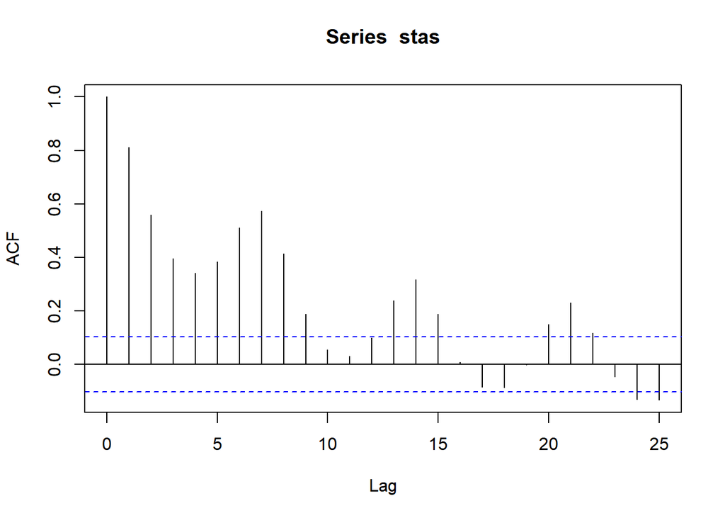

```r
acf(stas)
```

### Uji ADF

```r
tseries::adf.test(stas)
```

```
##
##  Augmented Dickey-Fuller Test
##
## data:  stas
## Dickey-Fuller = -4.6888, Lag order = 7, p-value = 0.01
## alternative hypothesis: stationary
```

$H_0$ : Data tidak stasioner dalam rataan

$H_1$ : Data stasioner dalam rataan

### Plot Box-Cox

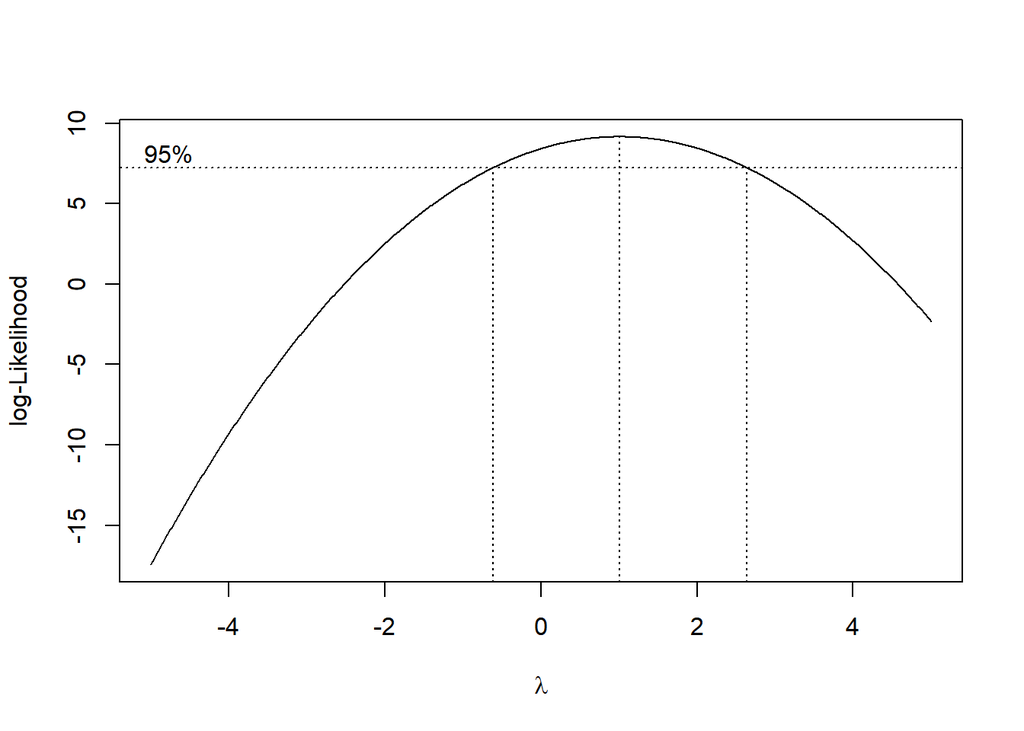

```r
index <- seq(1:365)
bc = boxcox(stas~index, lambda = seq(-5,5,by=0.01))
```

```r
#Nilai Rounded Lambda
lambda <- bc$x[which.max(bc$y)]
lambda
```

```
## [1] 1.01
```

```r
#SK
bc$x[bc$y > max(bc$y) - 1/2 * qchisq(.95,1)]
```

```
##   [1] -0.61 -0.60 -0.59 -0.58 -0.57 -0.56 -0.55 -0.54 -0.53 -0.52 -0.51 -0.50
##  [13] -0.49 -0.48 -0.47 -0.46 -0.45 -0.44 -0.43 -0.42 -0.41 -0.40 -0.39 -0.38
##  [25] -0.37 -0.36 -0.35 -0.34 -0.33 -0.32 -0.31 -0.30 -0.29 -0.28 -0.27 -0.26
##  [37] -0.25 -0.24 -0.23 -0.22 -0.21 -0.20 -0.19 -0.18 -0.17 -0.16 -0.15 -0.14
##  [49] -0.13 -0.12 -0.11 -0.10 -0.09 -0.08 -0.07 -0.06 -0.05 -0.04 -0.03 -0.02
##  [61] -0.01  0.00  0.01  0.02  0.03  0.04  0.05  0.06  0.07  0.08  0.09  0.10
##  [73]  0.11  0.12  0.13  0.14  0.15  0.16  0.17  0.18  0.19  0.20  0.21  0.22
##  [85]  0.23  0.24  0.25  0.26  0.27  0.28  0.29  0.30  0.31  0.32  0.33  0.34
##  [97]  0.35  0.36  0.37  0.38  0.39  0.40  0.41  0.42  0.43  0.44  0.45  0.46
## [109]  0.47  0.48  0.49  0.50  0.51  0.52  0.53  0.54  0.55  0.56  0.57  0.58
## [121]  0.59  0.60  0.61  0.62  0.63  0.64  0.65  0.66  0.67  0.68  0.69  0.70
## [133]  0.71  0.72  0.73  0.74  0.75  0.76  0.77  0.78  0.79  0.80  0.81  0.82
## [145]  0.83  0.84  0.85  0.86  0.87  0.88  0.89  0.90  0.91  0.92  0.93  0.94
## [157]  0.95  0.96  0.97  0.98  0.99  1.00  1.01  1.02  1.03  1.04  1.05  1.06
## [169]  1.07  1.08  1.09  1.10  1.11  1.12  1.13  1.14  1.15  1.16  1.17  1.18
## [181]  1.19  1.20  1.21  1.22  1.23  1.24  1.25  1.26  1.27  1.28  1.29  1.30
## [193]  1.31  1.32  1.33  1.34  1.35  1.36  1.37  1.38  1.39  1.40  1.41  1.42
## [205]  1.43  1.44  1.45  1.46  1.47  1.48  1.49  1.50  1.51  1.52  1.53  1.54
## [217]  1.55  1.56  1.57  1.58  1.59  1.60  1.61  1.62  1.63  1.64  1.65  1.66
## [229]  1.67  1.68  1.69  1.70  1.71  1.72  1.73  1.74  1.75  1.76  1.77  1.78
## [241]  1.79  1.80  1.81  1.82  1.83  1.84  1.85  1.86  1.87  1.88  1.89  1.90
## [253]  1.91  1.92  1.93  1.94  1.95  1.96  1.97  1.98  1.99  2.00  2.01  2.02
## [265]  2.03  2.04  2.05  2.06  2.07  2.08  2.09  2.10  2.11  2.12  2.13  2.14
## [277]  2.15  2.16  2.17  2.18  2.19  2.20  2.21  2.22  2.23  2.24  2.25  2.26
## [289]  2.27  2.28  2.29  2.30  2.31  2.32  2.33  2.34  2.35  2.36  2.37  2.38
## [301]  2.39  2.40  2.41  2.42  2.43  2.44  2.45  2.46  2.47  2.48  2.49  2.50
## [313]  2.51  2.52  2.53  2.54  2.55  2.56  2.57  2.58  2.59  2.60  2.61  2.62
## [325]  2.63
```

Gambar di atas menunjukkan nilai *rounded value* ($\lambda$) optimum sebesar **1,01** dan pada selang kepercayaan 95% nilai memiliki batas bawah **-0,61** dan batas atas **2,63**. Selang tersebut memuat nilai satu sehingga dapat dikatakan bahwa data stasioner dalam ragam.

### Partisi Data

#### Bagian 1

```r
dt_stas1 <- stas[1:88] |> ts()
mean(dt_stas1)
```

```
## [1] 30.67634
```

```r
var(dt_stas1)
```

```
## [1] 2.867363
```

#### Plot Time Series

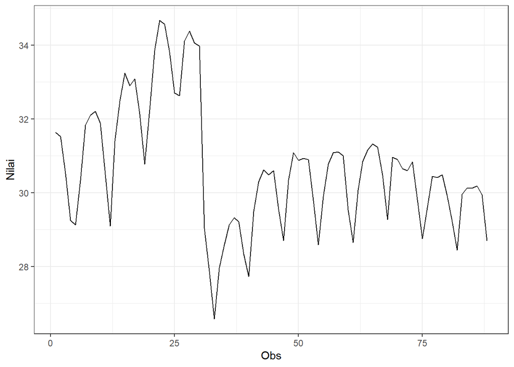

```r
dt_stas1 |> as_tsibble() |>
  ggplot(aes(x = index, y = value)) +
  geom_line() + theme_bw() +
  xlab("Obs") + ylab("Nilai")
```

Plot deret waktu di atas menunjukkan bahwa data tidak stasioner dalam rataan, ditandai dengan data yang tidak menyebar di sekitar nilai tengahnya

Selain itu, data cenderung stasioner dalam ragam, ditandai dengan lebar pita yang cenderung sama.

#### Plot ACF

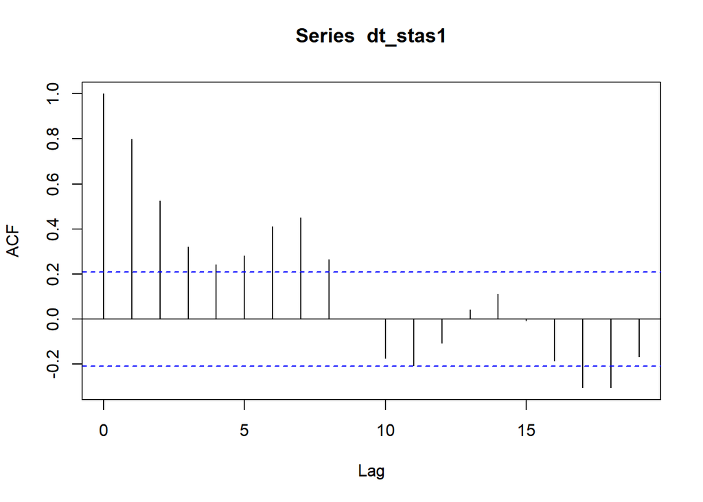

```r
acf(dt_stas1)
```

Berdasarkan plot ACF, terlihat bahwa plot ACF pada data tersebut cenderung *tails off* dan membentuk grafik sinus. Berarti, belum stastioner.

#### Uji ADF

```r
tseries::adf.test(dt_stas1)
```

```
##
##  Augmented Dickey-Fuller Test
##
## data:  dt_stas1
## Dickey-Fuller = -2.6198, Lag order = 4, p-value = 0.3212
## alternative hypothesis: stationary
```

$H_0$ : Data tidak stasioner dalam rataan

$H_1$ : Data stasioner dalam rataan

#### Plot Boxcox

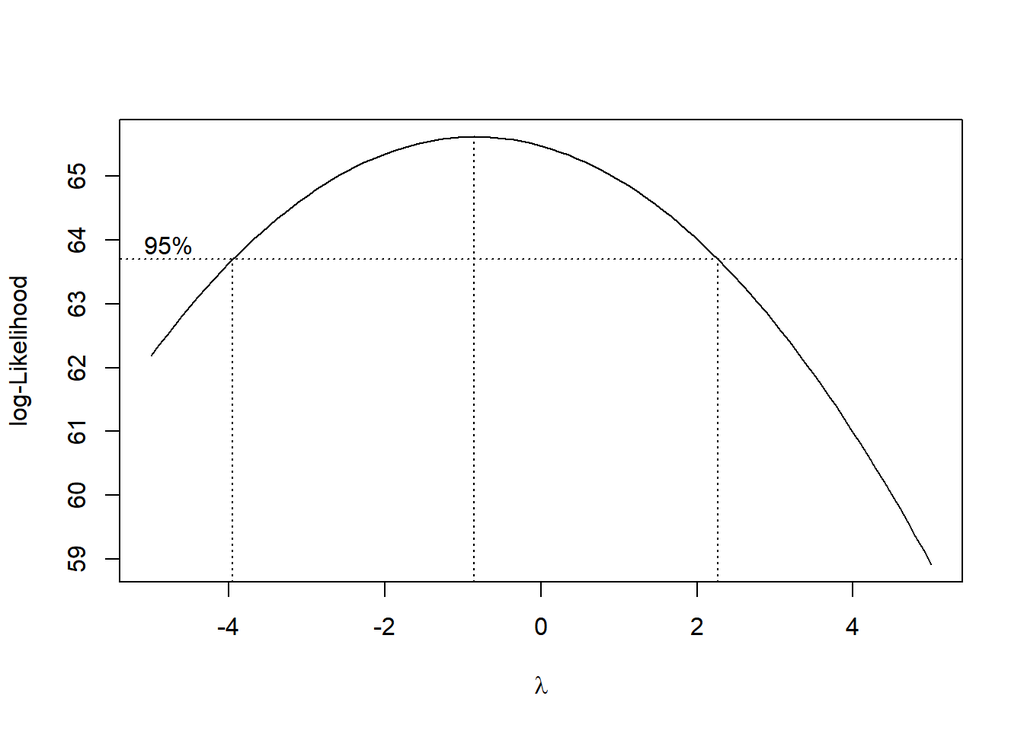

```r
index <- seq(1:88)
bc = boxcox(dt_stas1~index, lambda = seq(-5,5,by=1))
```

```r
#Nilai Rounded Lambda
lambda <- bc$x[which.max(bc$y)]
lambda
```

```
## [1] -0.8585859
```

```r
#SK
bc$x[bc$y > max(bc$y) - 1/2 * qchisq(.95,1)]
```

```
##  [1] -3.88888889 -3.78787879 -3.68686869 -3.58585859 -3.48484848 -3.38383838
##  [7] -3.28282828 -3.18181818 -3.08080808 -2.97979798 -2.87878788 -2.77777778
## [13] -2.67676768 -2.57575758 -2.47474747 -2.37373737 -2.27272727 -2.17171717
## [19] -2.07070707 -1.96969697 -1.86868687 -1.76767677 -1.66666667 -1.56565657
## [25] -1.46464646 -1.36363636 -1.26262626 -1.16161616 -1.06060606 -0.95959596
## [31] -0.85858586 -0.75757576 -0.65656566 -0.55555556 -0.45454545 -0.35353535
## [37] -0.25252525 -0.15151515 -0.05050505  0.05050505  0.15151515  0.25252525
## [43]  0.35353535  0.45454545  0.55555556  0.65656566  0.75757576  0.85858586
## [49]  0.95959596  1.06060606  1.16161616  1.26262626  1.36363636  1.46464646
## [55]  1.56565657  1.66666667  1.76767677  1.86868687  1.96969697  2.07070707
## [61]  2.17171717
```

Gambar di atas menunjukkan nilai *rounded value* ($\lambda$) optimum sebesar **-0.8585859** dan pada selang kepercayaan 95% nilai memiliki batas bawah **-3.88888889** dan batas atas **2.17171717**. Selang tersebut memuat nilai satu sehingga dapat dikatakan bahwa data stasioner dalam ragam.

#### Bagian 2

```r
dt_stas2 <- stas[1:270] |> ts()
mean(dt_stas2)
```

```
## [1] 30.38095
```

```r
var(dt_stas2)
```

```
## [1] 2.622748
```

#### Plot Time Series

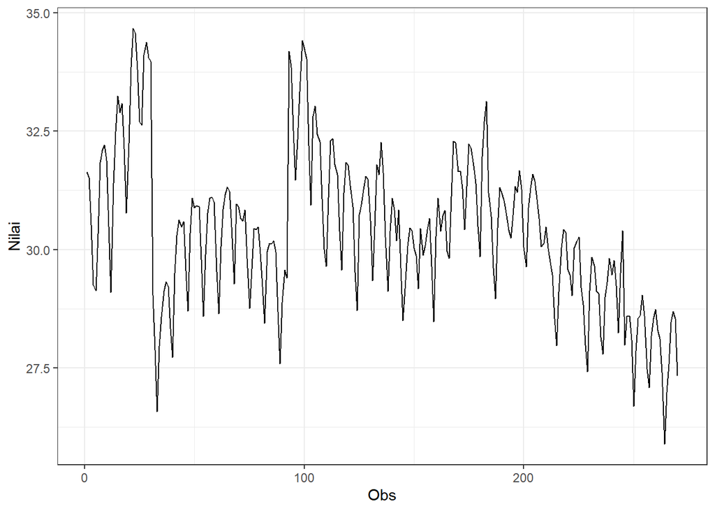

```r
dt_stas2 |> as_tsibble() |>
  ggplot(aes(x = index, y = value)) +
  geom_line() + theme_bw() +
  xlab("Obs") + ylab("Nilai")
```

Plot deret waktu di atas menunjukkan bahwa data tidak stasioner dalam rataan, ditandai dengan data yang tidak menyebar di sekitar nilai tengahnya dan stasioner dalam ragam, ditandai dengan lebar pita yang cenderung sama.

#### Plot ACF

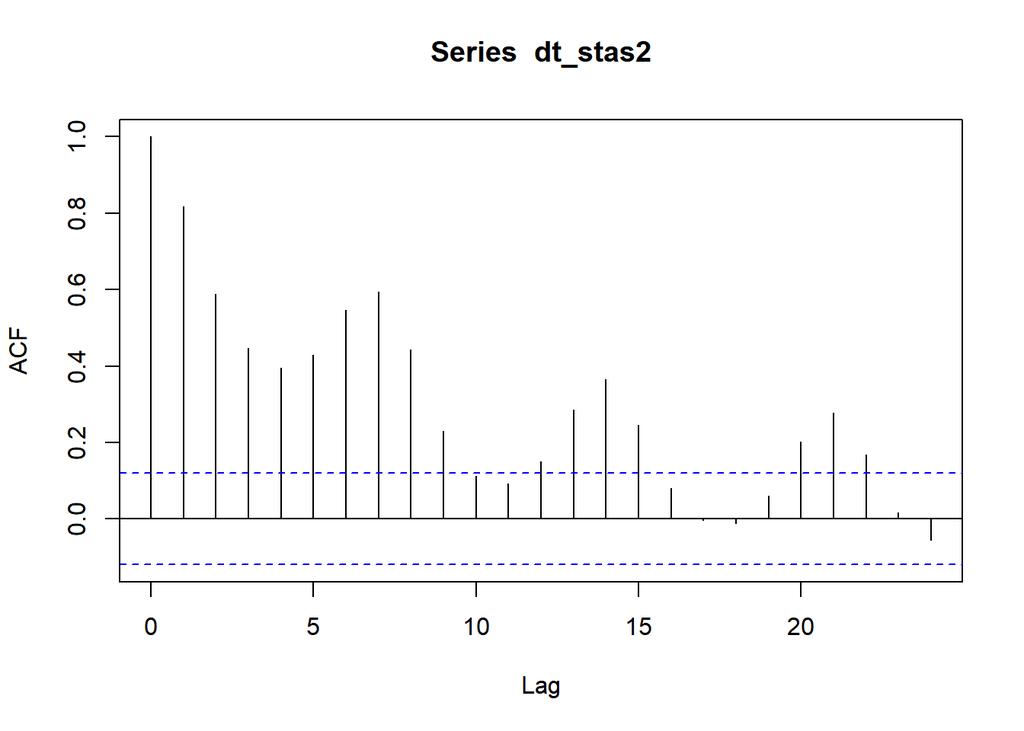

```r
acf(dt_stas2)
```

Berdasarkan plot ACF, terlihat bahwa plot ACF pada data tersebut cenderung tails off. Berarti, belum stasioner.

#### Uji ADF

```r
tseries::adf.test(dt_stas2)
```

```
##
##  Augmented Dickey-Fuller Test
##
## data:  dt_stas2
## Dickey-Fuller = -2.4038, Lag order = 6, p-value = 0.4059
## alternative hypothesis: stationary
```

$H_0$ : Data tidak stasioner dalam rataan

$H_1$ : Data stasioner dalam rataan

Berdasarkan uji ADF tersebut, didapat *p-value* sebesar 0.4059 yang lebih besar dari taraf nyata 5% sehingga tak tolak $H_0$ dan menandakan bahwa data tidak stasioner dalam rataan. Hal ini sesuai dengan hasil eksplorasi menggunakan plot time series dan plot ACF.

#### Plot Boxcox

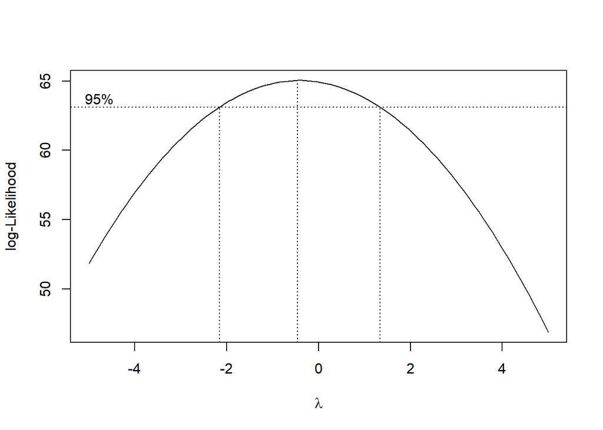

```r
index <- seq(1:270)
bc = boxcox(dt_stas2~index, lambda = seq(-5,5,by=1))
```

```r
#Nilai Rounded Lambda
lambda <- bc$x[which.max(bc$y)]
lambda
```

```
## [1] -0.4545455
```

```r
#SK
bc$x[bc$y > max(bc$y) - 1/2 * qchisq(.95,1)]
```

```
##  [1] -2.07070707 -1.96969697 -1.86868687 -1.76767677 -1.66666667 -1.56565657
##  [7] -1.46464646 -1.36363636 -1.26262626 -1.16161616 -1.06060606 -0.95959596
## [13] -0.85858586 -0.75757576 -0.65656566 -0.55555556 -0.45454545 -0.35353535
## [19] -0.25252525 -0.15151515 -0.05050505  0.05050505  0.15151515  0.25252525
## [25]  0.35353535  0.45454545  0.55555556  0.65656566  0.75757576  0.85858586
## [31]  0.95959596  1.06060606  1.16161616  1.26262626
```

Gambar di atas menunjukkan nilai *rounded value* ($\lambda$) optimum sebesar **-0.4545455** dan pada selang kepercayaan 95% nilai memiliki batas bawah **-2.07070707** dan batas atas **1.26262626**. Selang tersebut memuat nilai satu sehingga dapat dikatakan bahwa data bangkitan stasioner dalam ragam.

Didapatkan bahwa data tidak stasioner dalam rataan, dan stasioner dalam ragam.